# Question 2. K-nearest neighbors

With information of over 29,000 Mercedes-Benz S Class vehicles, our goal is to use K-nearest neighbors to build a predictive model for price, given mileage, separately for each of two trim levels: 350 and 65 AMG.

## Model for MB S350

### Figure 2.1.

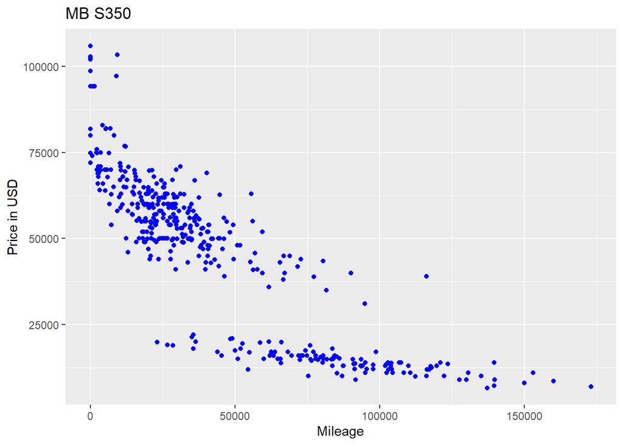

In the figure 2.1. we can see the negative relation between the mileage and the price, as expected.

The following steep is divide our data between the test and train data for both variables. After that, we generate random samples of our subsets of data. Then, we calculate the rsme generated at each level of K in our k nearest neighbor model for price of a 350 s class given the mileage.

### Figure 2.2.

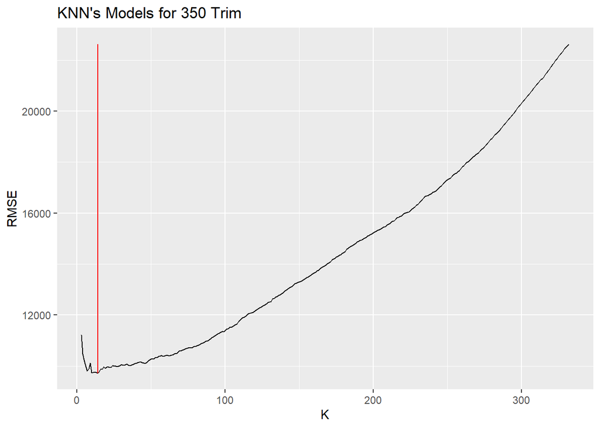

The figure 2.2. shows the series of RMSE at every value of K, the red line indicate the k which generate the minimum RMSE. In this case the k value is 14. However this value will change any time we generate a new random sample, to decide the best k we repeated the process ten times and then we took the average of the minium k.

### Figure 2.3.

```
## [1] 9725.448
```

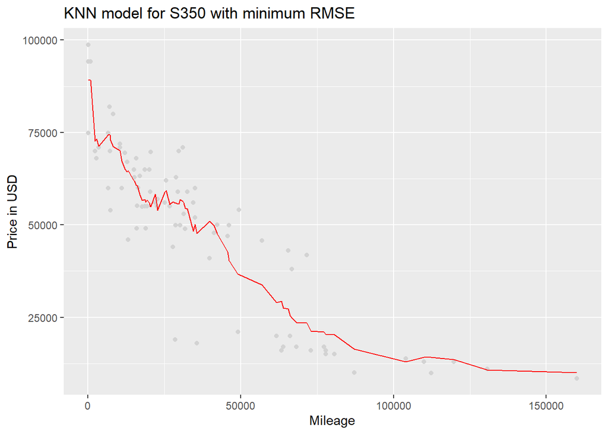

After run the model with the best k, we generate the fitted values to compare with our test subset. the figure 2.3. shows the fit of the chosen model.

## Model for MB S65AMG

Now we have to do the same process to find out what is the best model for the S65 AMG class.

### Figure 2.4.

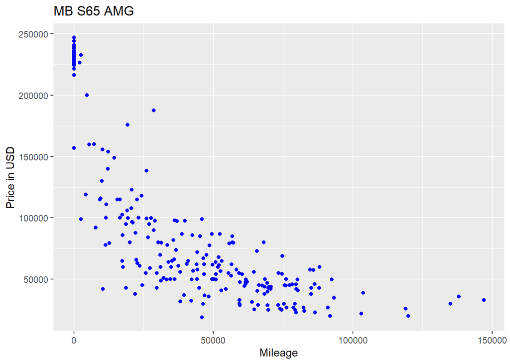

### Figure 2.5.

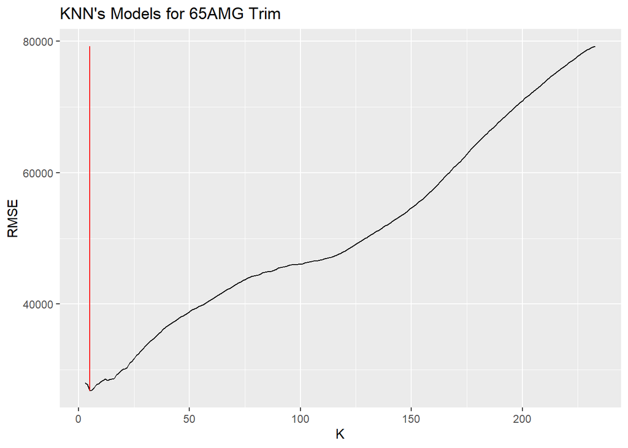

The figure 2.5. shows the series of RMSE at every value of K, the red line indicate the k which generate the minimum RMSE. In this case the k value which minimize the RMSE for S65 AMG trim is 5. However this value will change any time we generate a new random sample, to decide the best k we repeated the process ten times and then we took the average of the minium k.

### Figure 2.6.

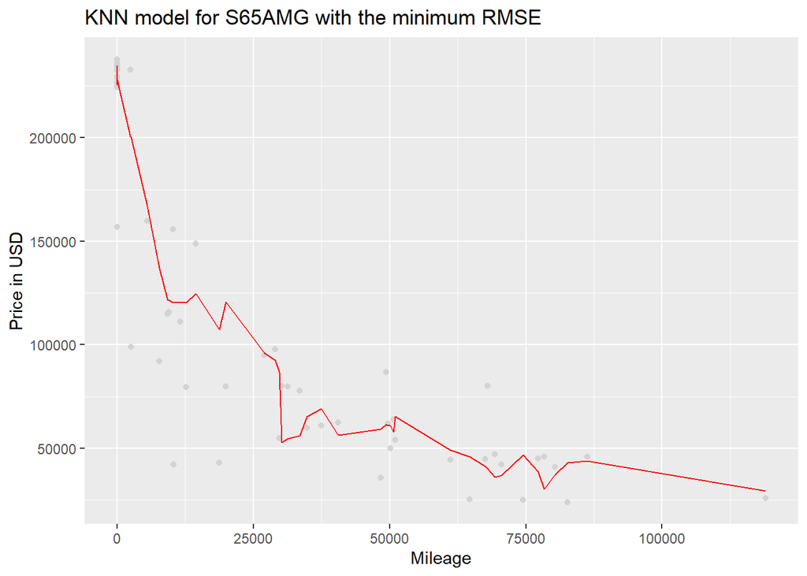

After run the model with the best k, we generate the fitted values to compare with our test subset. the figure 2.6. shows the fit of the chosen model.